# H&E to ST

## Introduction

We have two spatial transcriptomics samples with accompanying H&E images. The goal is to predict gene expression using random forests.

## Non-Spatial Random Forests

In this section, I’ll create two RF models (one for each of our two images) and use them to predict THY1 expression in the other sample.

### Sample 1 model

First, let’s try making a model based on sample 1

```
##
## Call:
##  randomForest(formula = THY1 ~ ., data = B1_binarized, ntree = 1000,      sampsize = c(90, 90), importance = TRUE)
##                Type of random forest: classification
##                      Number of trees: 1000
## No. of variables tried at each split: 10
##
##         OOB estimate of  error rate: 27.9%
## Confusion matrix:
##     0  1 class.error
## 0 139 47   0.2526882
## 1  30 60   0.3333333
```

### Sample 2 model

```
##
## Call:
##  randomForest(formula = THY1 ~ ., data = B2_binarized, ntree = 1000,      sampsize = c(100, 100), importance = TRUE)
##                Type of random forest: classification
##                      Number of trees: 1000
## No. of variables tried at each split: 10
##
##         OOB estimate of  error rate: 18.58%
## Confusion matrix:
##     0  1 class.error
## 0 149 31   0.1722222
## 1  24 92   0.2068966
```

## Prediction

Next, we’ll look at how the models perform when run on the opposite sample

```
##       Predicted
## Actual         1         2
##      1 0.8722222 0.1277778
##      2 0.8448276 0.1551724
```

```
##       Predicted
## Actual          1          2
##      1 0.97311828 0.02688172
##      2 0.96666667 0.03333333
```

We see that both models predict “1” (low THY1 expression) really well, but “2” (high THY1 expression) is being mis-classified frequently.

## Re-running workflow with global thresholding

One possible fix could be to use “global” thresholding, i.e. binarizing the data based on the GLOBAL mean.

```
## [1] 21.8986
```

Next, we’ll use this newly thresholded data to create new random forest models.

```
##
## Call:
##  randomForest(formula = THY1 ~ ., data = B1_binarized_new, ntree = 1000,      sampsize = c(80, 80), importance = TRUE)
##                Type of random forest: classification
##                      Number of trees: 1000
## No. of variables tried at each split: 10
##
##         OOB estimate of  error rate: 24.64%
## Confusion matrix:
##     0  1 class.error
## 0 150 46   0.2346939
## 1  22 58   0.2750000
```

```
##
## Call:
##  randomForest(formula = THY1 ~ ., data = B2_binarized_new, ntree = 1000,      sampsize = c(100, 100), importance = TRUE)
##                Type of random forest: classification
##                      Number of trees: 1000
## No. of variables tried at each split: 10
##
##         OOB estimate of  error rate: 21.28%
## Confusion matrix:
##     0   1 class.error
## 0 124  38   0.2345679
## 1  25 109   0.1865672
```

```
##       Predicted
## Actual          1          2
##      1 0.93209877 0.06790123
##      2 0.88805970 0.11194030
```

```
##       Predicted
## Actual          1          2
##      1 0.90816327 0.09183673
##      2 0.91250000 0.08750000
```

Misclassification for group 2 went down slightly but is still terrible…

## Let’s try spatialrf

```
## The model residuals are spatially correlated, fitting a spatial model.
```

```
## Using the distance matrix columns as spatial predictors.
```

```
## Details about the spatial predictors stored in model$spatial.
```

```
## Model type
##   - Fitted with:                     rf_spatial()
##   - rf_spatial() method:             hengl
##   - Response variable:               THY1
##
## Random forest parameters
##   - Type:                            Regression
##   - Number of trees:                 500
##   - Sample size:                     276
##   - Number of predictors:            376
##   - Mtry:                            19
##   - Minimum node size:               5
##
##
## Model performance
##   - R squared (oob):                  0.6457274
##   - R squared (cor(obs, pred)^2):     0.9605769
##   - Pseudo R squared (cor(obs, pred)):0.9800903
##   - RMSE (oob):                       13.91334
##   - RMSE:                             5.941
##   - Normalized RMSE:                  0.2795765
##
## Model residuals
##   - Stats:
##              ┌────────┬────────┬────────┬───────┬────────┬───────┐
##              │ Min.   │ 1st Q. │ Median │ Mean  │ 3rd Q. │ Max.  │
##              ├────────┼────────┼────────┼───────┼────────┼───────┤
##              │ -13.82 │  -2.63 │  -0.97 │ -0.11 │   0.56 │ 43.71 │
##              └────────┴────────┴────────┴───────┴────────┴───────┘
##   - Normality:
##       - Shapiro-Wilks W: 0.695
##       - p-value        : 0
##       - Interpretation : Residuals are not normal
##
##   - Spatial autocorrelation:
##              ┌──────────┬───────────┬─────────┬──────────────────┐
##              │ Distance │ Moran's I │ P value │ Interpretation   │
##              ├──────────┼───────────┼─────────┼──────────────────┤
##              │      0.0 │    -0.000 │   0.408 │ No spatial       │
##              │          │           │         │ correlation      │
```

[output cut: 210 more lines]

```
##               ├────────────────────────────────────┼────────────┤
##               │ X53                                │     -0.469 │
##               ├────────────────────────────────────┼────────────┤
##               │ spatial_predictors (min)           │     -0.491 │
##               ├────────────────────────────────────┼────────────┤
##               │ X50                                │     -0.532 │
##               ├────────────────────────────────────┼────────────┤
##               │ X0                                 │     -0.590 │
##               ├────────────────────────────────────┼────────────┤
##               │ X79                                │     -0.612 │
##               ├────────────────────────────────────┼────────────┤
##               │ X84                                │     -0.755 │
##               ├────────────────────────────────────┼────────────┤
##               │ X33                                │     -0.762 │
##               └────────────────────────────────────┴────────────┘
```

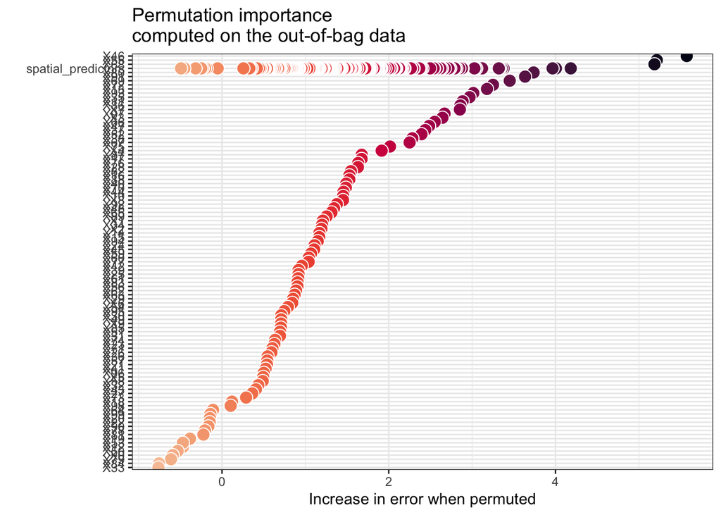

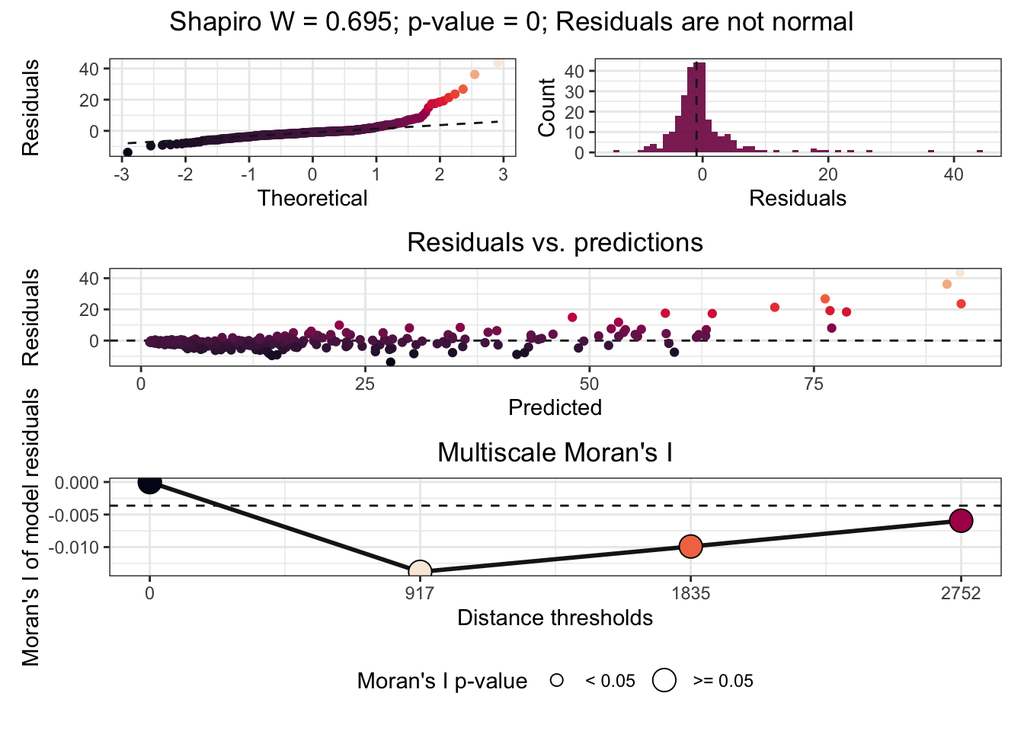

The SpatialRF model has a decent OOB R-squared and its other R-squared values are excellent. However, SpatialRF doesn’t have functionality that supports prediction. I’m looking to see if there’s a way I can implement my own prediction function based on the output of SpatialRF.

## Prediction with SpatialML

SpatialML, however, *does* include functionality for prediction, so I’m giving that a shot next.

### Building the Model

First, I built a model using sample 2

```
##
## Number of Observations: 296
```

```
## Number of Independent Variables: 100
```

```
## Kernel: Adaptive
## Neightbours: 5
```

```
## Number of Variables: 100
```

```
##
## --------------- Global Model Summary ---------------
```

```
##
## Residual Sum of Squares (Predicted): 13805.961
```

```
## R-squared (Predicted) %: 91.078
```

```
##
## --------------- Local Model Summary ---------------
```

```
##
## Residuals OOB:
```

```
##
## Residuals Predicted:
```

```
##
## %IncMSE:
```

```
##
## %IncNodePurity:
```

```
##
## Residual Sum of Squares (OOB): 90947.802
```

```
## R-squared (OOB) %: 41.226
```

```
## Residual Sum of Squares (Predicted): 13385.444
```

```
## R-squared (Predicted) %: 91.35
```

```
## [1] "OOB R^2:  0.412255720230724"
```

```
## [1] "Predicted R^2:  0.913497435165428"
```

The OOB accuracy isn’t great, but the predicted R-squared is quite high.

### Predicting THY1 expression for sample 1

Next, I used this model to predict THY1 expression for the first dataset.

### Statistical measures for accuracy

The SpatialML prediction function doesn’t give any statistics relating to accuracy, and I’ve seen a few different ways of measuring accuracy.

#### Linear Regression

Linear regression can give some insight into relation between actual and predicted THY1. Actual THY1 expression is not normal (heavily right skewed) so these results should be taken with a grain of salt…

```
##
## Call:
## lm(formula = predicted_expression ~ THY1, data = with_predictions)
##
## Residuals:
##     Min      1Q  Median      3Q     Max
## -36.432 -10.231  -0.864   9.243  61.180
##
## Coefficients:
##             Estimate Std. Error t value Pr(>|t|)
## (Intercept) 20.32155    1.08892  18.662  < 2e-16 ***
## THY1         0.20617    0.03648   5.652 3.98e-08 ***
## ---
## Signif. codes:  0 '***' 0.001 '**' 0.01 '*' 0.05 '.' 0.1 ' ' 1
##
## Residual standard error: 14.14 on 274 degrees of freedom
## Multiple R-squared:  0.1044, Adjusted R-squared:  0.1011
## F-statistic: 31.94 on 1 and 274 DF,  p-value: 3.978e-08
```

There is a linear relationship, however based on the THY1 coefficient, the predicted values are about 20% of what the actual THY1 values are.

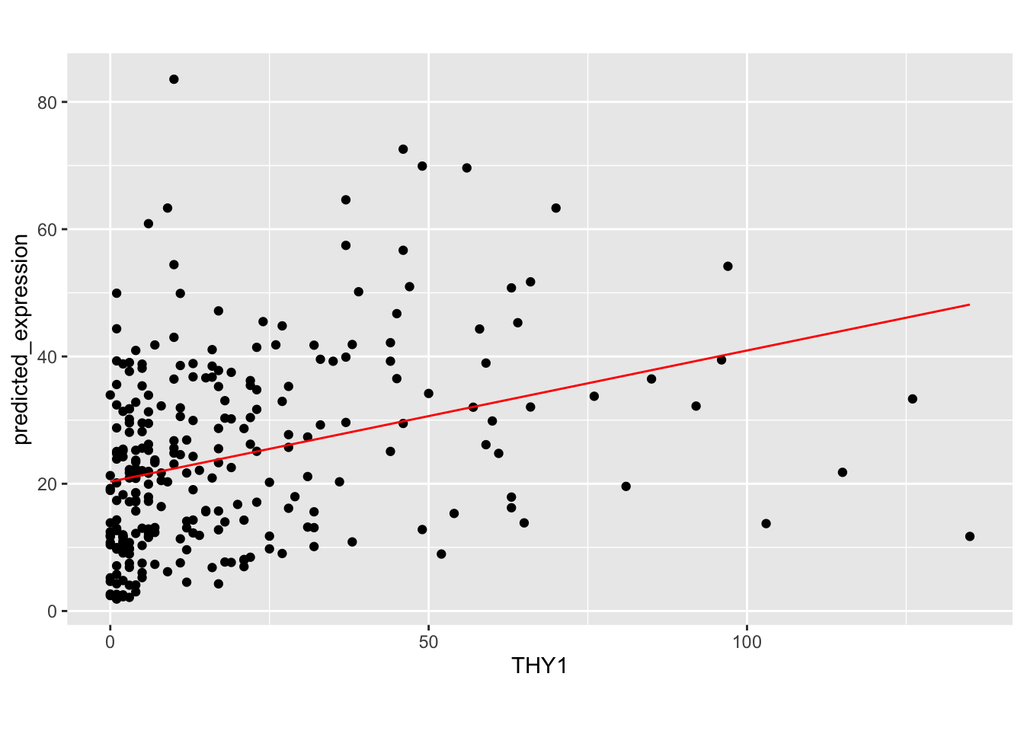

#### Spearman Correlation

Another method of comparison is using Spearman Correlation. This was used in (this paper)[https://cancerres.aacrjournals.org/content/81/19/5115] which predicts *bulk* RNA expression from H&E slides.

```
##
##  Spearman's rank correlation rho
##
## data:  with_predictions$THY1 and with_predictions$predicted_expression
## S = 2096488, p-value = 3.989e-12
## alternative hypothesis: true rho is not equal to 0
## sample estimates:
##       rho
## 0.4016958
```

The expression values ARE definitely correlated…

### Spatial patterns of accuracy

Next, I plotted THY1 expression. The second sample has higher overall THY1 expression, so it seems strange that running the model on the first sample would *under-predict* THY1 expression.

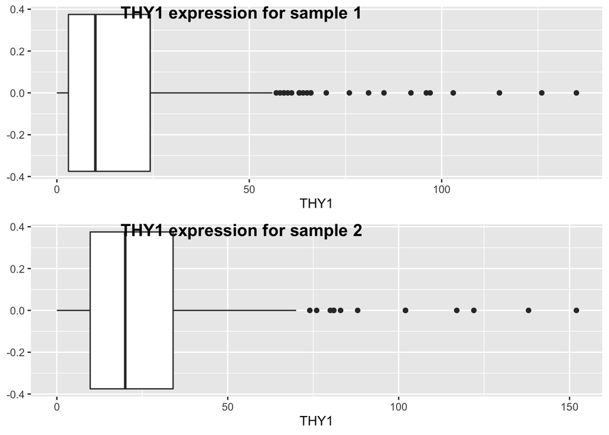

To further investigate, I looked at how accuracy of the model varied spatially.

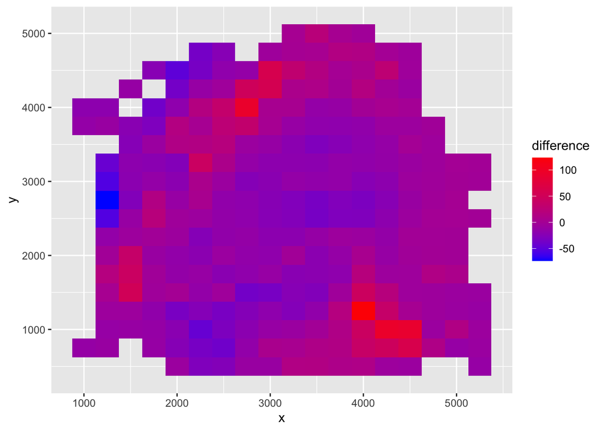

The plot above shows the difference in THY1 expression (actual expression - predicted expression). There are clear spatial trends, with definitive areas that have high vs. low differences.

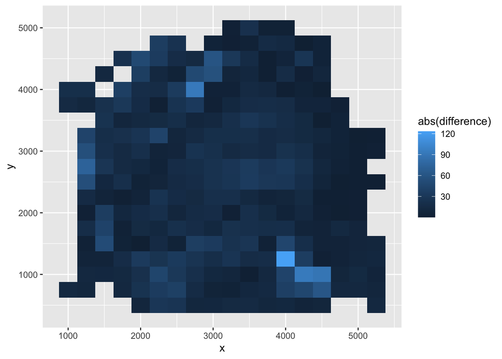

The above plot shows the absolute value of the difference, showing overall distance between actual and predicted expression. Light regions are less accurate (high difference between predicted and actual THY1 expression) and dark regions are more accurate (lower difference).